Universidad Nacional Autónoma de México - Licenciatura en ciencias genómicas

Introducción a Ciencia de Datos 2021 - Tarea 5

**Salvador González Juárez**

Realizar los siguientes ejercicios.

### 1. Comprueba la teoría de los grandes números para un dado de 6 caras. Genera muestras aleatorias de 10000 experimentos. Grafica la frecuencia en la que sale un numero cualquiera (1 al 6), números pares y múltiplos de 3 (3 y 6) mientras aumentas el número de experimentos. Interpreta tus resultados.

```r
# Importar las librerias requeridas
require(dplyr)
require(purrr)
```

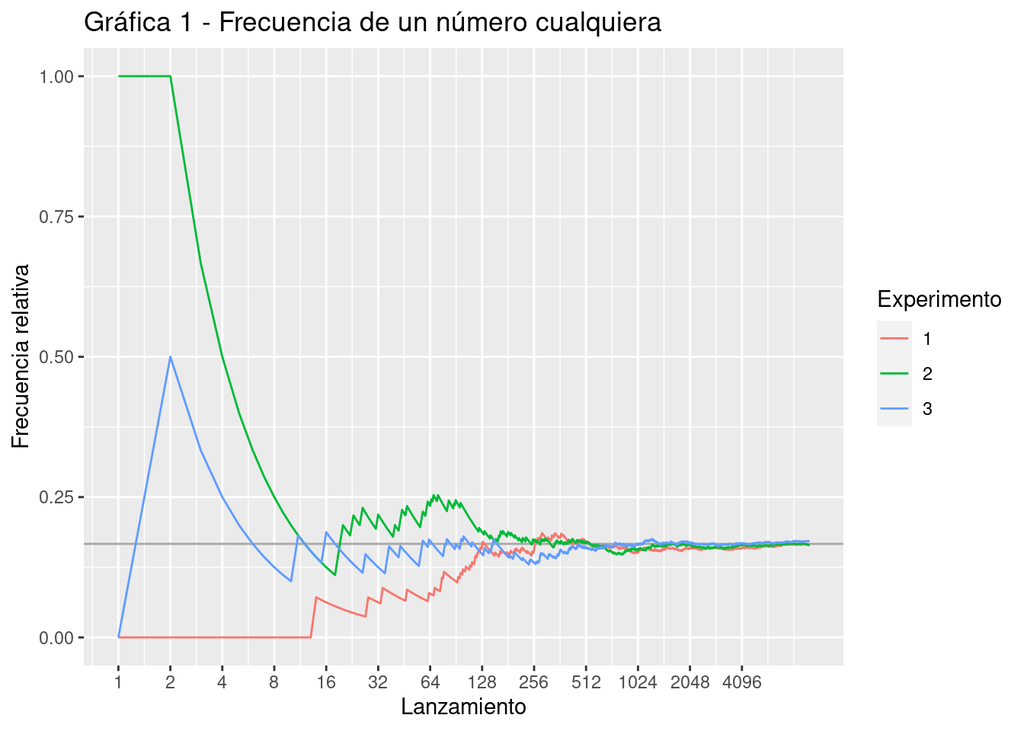

```r
require(ggplot2)
# Esta funcion realiza diez mil veces el ensayo de tirar un dado y
# calcula la media acumulada de la probabilidad de que salga un numero cualquiera
dado_1 <- function(n = 10000) {
 data.frame(num_lanzamiento = 1:n, lanzamiento = sample(c("1", "2", "3", "4", "5", "6"), n, replace = TRUE))%>%
    mutate(frec_rel = cummean(lanzamiento == "1"))
}

# Graficar un histograma de la frecuencia relativa de que salga un numero cualquiera al tirar un dado
set.seed(4)
map_df(1:3, ~dado_1(), .id = "serie") %>%
    ggplot(aes(x = log(num_lanzamiento), y = frec_rel, color = as.character(serie))) +
        geom_hline(yintercept = 1/6, color = "darkgray") +
        geom_line() +
        scale_x_continuous("Lanzamiento", labels = exp,
            breaks = log(sapply(0:12, function(i) 2 ^ i))) +
        labs(color = "Experimento", y = "Frecuencia relativa", title = "Gráfica 1 - Frecuencia de un número cualquiera")
```

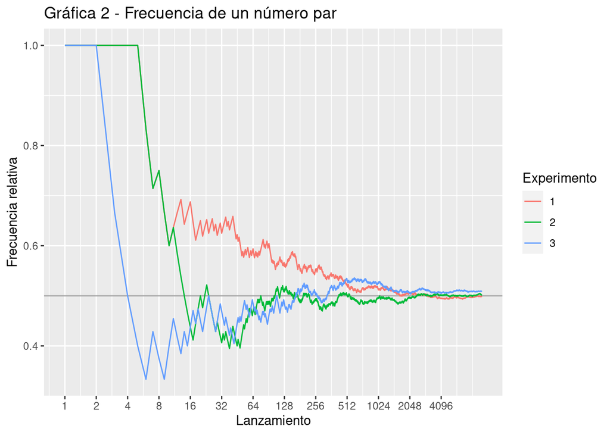

```r
# Esta funcion realiza diez mil veces el ensayo de tirar un dado y
# calcula la media acumulada de la probabilidad de que salga un numero par
dado_3 <- function(n = 10000) {
 data.frame(num_lanzamiento = 1:n, lanzamiento = sample(c("1", "2", "3", "4", "5", "6"), n, replace = TRUE))%>%
    mutate(frec_rel = cummean(lanzamiento == "2" | lanzamiento == "4" | lanzamiento == "6"))
}

# Graficar un histograma de la frecuencia relativa de que salga un numero par al tirar un dado
set.seed(8)
map_df(1:3, ~dado_3(), .id = "serie") %>%
    ggplot(aes(x = log(num_lanzamiento), y = frec_rel, color = as.character(serie))) +
        geom_hline(yintercept = 3/6, color = "darkgray") +
        geom_line() +
        scale_x_continuous("Lanzamiento", labels = exp,
            breaks = log(sapply(0:12, function(i) 2 ^ i))) +
        labs(color = "Experimento", y = "Frecuencia relativa", title = "Gráfica 2 - Frecuencia de un número par")
```

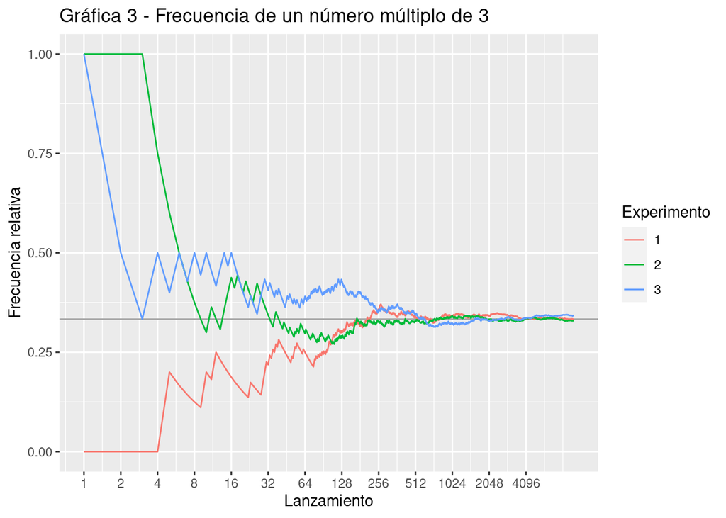

```r
# Esta funcion realiza diez mil veces el ensayo de tirar un dado y
# calcula la media acumulada de la probabilidad de que salga un numero multiplo de 3
dado_2 <- function(n = 10000) {
 data.frame(num_lanzamiento = 1:n, lanzamiento = sample(c("1", "2", "3", "4", "5", "6"), n, replace = TRUE))%>%
    mutate(frec_rel = cummean(lanzamiento == "3" | lanzamiento == "6"))
}

# Graficar un histograma de la frecuencia relativa de que salga un numero multiplo de 3 al tirar un dado
set.seed(15)
map_df(1:3, ~dado_2(), .id = "serie") %>%
    ggplot(aes(x = log(num_lanzamiento), y = frec_rel, color = as.character(serie))) +
        geom_hline(yintercept = 2/6, color = "darkgray") +
        geom_line() +
        scale_x_continuous("Lanzamiento", labels = exp,
            breaks = log(sapply(0:12, function(i) 2 ^ i))) +
        labs(color = "Experimento", y = "Frecuencia relativa", title = "Gráfica 3 - Frecuencia de un número múltiplo de 3")
```

Las gráficas presentadas previamente demuestran que la llamda “Ley de los grndes números” se cumple en el experimento de lanzar varias veces un dado. Mientras mayor sea la cantidad de ensayos realizados, las frecuencias de que salgan ciertos resultados tienden a normalizarse con respecto a un valor que corresponde a la proporción de dichos resultados entre la cantidad de resultados totales. En la **Gráfica 1** se puede observar que conforme aumenta el número de ensayos, la frecuencia de que salga un valor específico tiende a 1/6. Por su parte, en la **Gráfica 2** se puede observar que conforme aumenta el número de ensayos, la frecuencia de que salga un valor par tiende a 3/6. Finalmente, en la **Gráfica 3** se puede observar que conforme aumenta el número de ensayos, la frecuencia de que salga un valor múltiplo de tres tiende a 2/6.

### 2. Teorema de Bayes. Una fábrica de piezas para aviones está organizada en tres secciones. La sección A fabrica el 25% de las piezas, la sección B el 40% , mientras que el resto se fabrican en la sección C. La probabilidad de encontrar una pieza defectuosa es del 0.015, 0.025 y 0.009 según se considere la sección A, B o C, respectivamente. Si juntamos toda la producción calcula:

**1. La probabilidad de que una pieza al azar sea defectuosa**

Para calcularla, es necesario multiplicar la probabilidad de encontrar una pieza defectuosa por la proporcion de la producción de la sección, para cada una de ellas, y luego sumar todos los productos.

```r
PT <- (PA = 0.015*0.25) + (PB = 0.025*0.40) + (PC = 0.009*0.35)
PT
```

```
## [1] 0.0169
```

La probabilidad de que una pieza sea defectuosa, sin importar su sección de origen, es de **0.0169**.

**2. Dado que una pieza es defectuosa, calcula la probabilidad de que venga de cada fábrica**

Para calcular la probabilidad de que suceda cada evento, es necesario aplicar la fórmula del teorema de Bayes.

```r
PA / PT
```

```
## [1] 0.2218935
```

```r
PB / PT
```

```
## [1] 0.591716
```

```r
PC / PT
```

```
## [1] 0.1863905
```

La probabilidad de que una pieza defectuosa venga de la **sección A** es de **0.2218935**; para la **sección B** es de **0.591716**; y para la **sección C** es de **0.1863905**.

### 3. Con los datos de la tarea anterior Tarea 4, concluye si existe una diferencia entre hombres y mujeres para la característica que escogiste, pero esta vez desde un punto de vista bayesiano, realiza un t test bayesiano. Interpreta tus resultados. Este estudio es confiable o existe uno más apropiado? (no es necesario que hagas el análisis adecuado solo explica por qué).

Voy a volver a analizar si la diferencia entre el peso de cada género es significativa, y por ende, dependiente al mismo. Para ello voy a realizar el t test bayesiano. Primero obtengo los datos y los filtro conforme los estándares de la tarea pasada.

```r
# Leer el archivo
setwd("/home/salvador/Documentos/Licenciatura_Ciencias_Genomicas/Cuarto_Semestre/Ciencia_Datos/Tarea_5")
data <- read.table("../Tarea_2/cardiovascular_disease.csv", sep = ",", header = T)

# Eliminar los valores nulos para no tener errores
data <- na.omit(data)

# Filtrar los datos para que cumplan con valores viables
data_filtered <- data[data$weight >= 40 & data$weight <= 165,]

# Analizar los valores del peso filtrados
summary(data_filtered$weight)
```

```
##    Min. 1st Qu.  Median    Mean 3rd Qu.    Max.
##    40.0    65.0    72.0    74.2    82.0   165.0
```

A continuación, voy a demostrar gráficamente la distribución del peso para cada género.

```r
# Importar la libreria requerida para realizar la codificacion de datos
library(qdap)
```

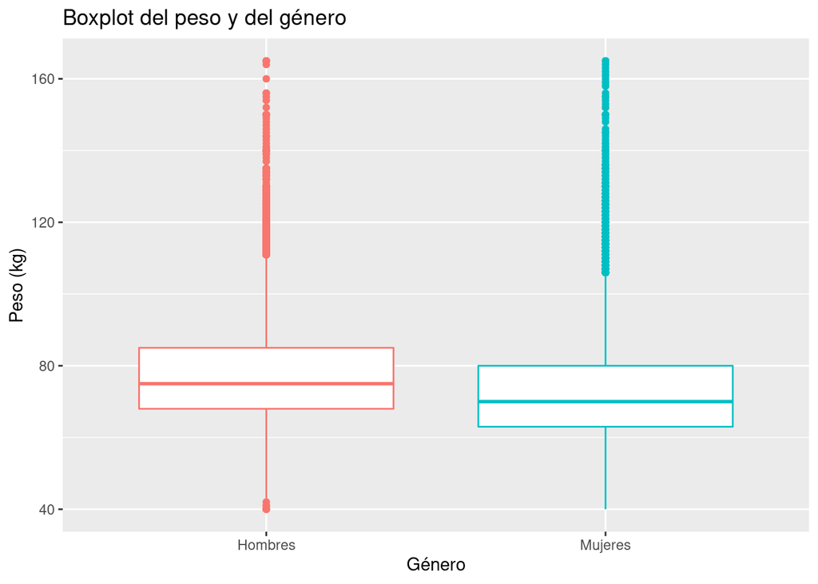

```r
# Establecer un tipo de variable valido para la categoria de genero, para no tener errores
data_filtered$gender <- multigsub(sort(unique(data_filtered$gender)), c("Mujeres", "Hombres"), data_filtered$gender)

# Graficar la distribucion de ambos conjuntos en un grafico de boxplot
ggplot(data_filtered, aes(x = gender, y = weight, color = gender)) +
    geom_boxplot() +
    theme(legend.position = "none") +
    labs(title = "Boxplot del peso y del género", x = "Género", y = "Peso (kg)") +
    scale_x_discrete(labels = sort(unique(data_filtered$gender)))
```

Podemos observar que los hombres tienden a pesar en promedio más que las mujeres, lo cual fue demostrado en la anterior tarea mediante una perspectiva frecuentista. Ahora voy a analizar esta diferencia mediante una perspectiva bayesiana.

```r
# Importar la libreria para realizar el t test de bayesiano
require(BayesFactor)
# Realizar el t test bayesiano para ver si hay relacion entre el genero y el peso
ttestBF(x = data_filtered[data_filtered$gender=="Mujeres",]$weight, y = data_filtered[data_filtered$gender=="Hombres",]$weight, paired = FALSE)
```

```
## t is large; approximation invoked.
```

```
## Bayes factor analysis
## --------------
## [1] Alt., r=0.707 : 1.355684e+369 ±0%
##
## Against denominator:
##   Null, mu1-mu2 = 0
## ---
## Bayes factor type: BFindepSample, JZS
```

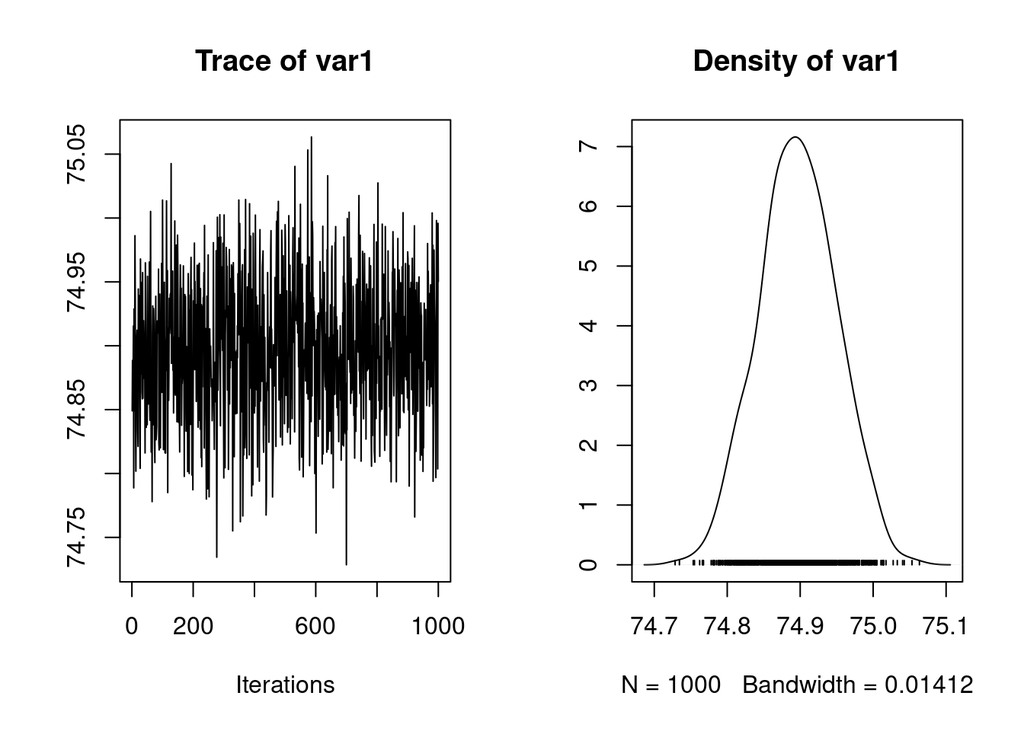

```r
# Mostrar como se comporta la media de las muestras mediante graficas.
samples = ttestBF(x = data_filtered[data_filtered$gender=="Mujeres",]$weight,
y = data_filtered[data_filtered$gender=="Hombres",]$weight, paired = FALSE,
posterior = TRUE, iterations = 1000)
plot(samples[,"mu"])
```

El factor de Bayes para este análisis es de 1.355684e+369, el cual es un número muy grande, por lo tanto hay una fuerte evidencia a favor de que existe una relación entre el peso de los individuos y el género que poseen. Además esto concuerda con mis resultados de la tarea anterior, donde establecí que los hombres tienden a ser más pesados. Finalmente, considero que este test puede ser confiable, pero esto depende mucho de si os datos están filtrados o no. Además hago una pequeña observación en los gráficos del análisis a posteriori, pues la media de la distribución no está de acuerdo con la media calculada previo al análisis. No estoy seguro si esto es normal, o si en realidad podría dar indicios de que el método no es tan acertado como aparenta.